# Assignment_descriptive_1_0100

## E1:

Given the dataset "ap" below,

1. use the ap.describe() to get the basic statistics, print the result.
2. Explain the meaning of "count", "mean", "std", "min", "25\%", in the result.
3. Plot the histogram of "wkd_day_value", i.e. ap["wkd_day_value"], is it skewed?
4. Write a function to calculate skewness. (Skewness = $\sum_i^N (X_i – X_{mean})^3 / (N-1) * σ^3$).
5. Apply this function to calculate the skewness to the Series ap["wkd_day_value"].
6. Answer the question: is the distribution of ap["wkd_day_value"] normal, and why?

```python
import pandas as pd
import seaborn as sns
# localised version
spreadurl = '../raw.githubusercontent.com/mengluchu/uncertainty/master/data_vis_exp/DENL17_uc.csv'
# load the data
ap = pd.read_csv(spreadurl).filter (regex="pop|nightlight|trop|ele|wind|temp|road|urban|wkd_day_value")
print(type(ap["wkd_day_value"]))
#ap["wkd_day_value"]
print( "===================================================================")
print( "1.")
# use the ap.describe() to get the basic statistics, print the result.
ap.describe()
```

```
<class 'pandas.core.series.Series'>
===================================================================
1.
```

|  | wkd_day_value | nightlight_450 | nightlight_4950 | nightlight_3150 | nightlight_900 | elevation | population_1000 | population_3000 | population_5000 | road_class_1_1000 | ... | wind_speed_10m_1 | wind_speed_10m_2 | wind_speed_10m_3 | wind_speed_10m_4 | wind_speed_10m_5 | wind_speed_10m_6 | wind_speed_10m_7 | wind_speed_10m_8 | wind_speed_10m_9 | urbantype |
| --- | --- | --- | --- | --- | --- | --- | --- | --- | --- | --- | --- | --- | --- | --- | --- | --- | --- | --- | --- | --- | --- |
| count | 482.000000 | 482.000000 | 482.000000 | 482.000000 | 482.000000 | 482.000000 | 482.000000 | 482.000000 | 482.000000 | 482.000000 | ... | 482.000000 | 482.000000 | 482.000000 | 482.000000 | 482.000000 | 482.000000 | 482.000000 | 482.000000 | 482.000000 | 482.000000 |
| mean | 26.954116 | 15.245239 | 9.044186 | 11.033635 | 14.686876 | 171.709049 | 6149.919575 | 41495.331104 | 94124.200708 | 1212.001476 | ... | 2.832647 | 3.396075 | 3.225519 | 2.954213 | 2.566703 | 3.003814 | 2.684772 | 2.510066 | 2.703582 | 2.406639 |
| std | 16.037734 | 13.472012 | 10.162684 | 10.997232 | 12.831380 | 210.356609 | 4504.243782 | 35000.951753 | 88325.729436 | 2705.754172 | ... | 0.582540 | 0.852448 | 0.611392 | 0.701939 | 0.644373 | 0.727757 | 0.522073 | 0.600255 | 0.660366 | 0.784860 |
| min | 2.615808 | 0.000000 | 0.000560 | 0.000000 | 0.000000 | -4.332134 | 0.000000 | 0.000000 | 552.417297 | 0.000000 | ... | 1.224902 | 1.105154 | 1.207697 | 1.108624 | 1.026124 | 1.021296 | 1.017121 | 0.875391 | 0.900630 | 1.000000 |
| 25% | 14.712573 | 4.665090 | 1.953545 | 2.928990 | 4.425944 | 26.100582 | 2219.177917 | 11524.904785 | 23243.484375 | 0.000000 | ... | 2.498561 | 2.862472 | 2.875859 | 2.399894 | 2.040184 | 2.458429 | 2.388771 | 2.101352 | 2.252375 | 2.000000 |
| 50% | 23.948446 | 13.828376 | 5.969375 | 8.181555 | 13.257292 | 94.629913 | 5981.528320 | 33830.275390 | 69034.738281 | 0.000000 | ... | 2.712368 | 3.238783 | 3.017025 | 2.866309 | 2.473387 | 2.902449 | 2.519323 | 2.463091 | 2.609148 | 3.000000 |
| 75% | 35.494337 | 22.387954 | 12.523816 | 16.410417 | 21.301006 | 237.837577 | 8995.891602 | 61942.635742 | 141487.503906 | 191.151607 | ... | 2.959297 | 3.685236 | 3.494962 | 3.329137 | 2.826228 | 3.264398 | 2.814551 | 2.727328 | 2.968780 | 3.000000 |
| max | 96.399710 | 83.368286 | 108.899269 | 105.218941 | 72.906769 | 1205.937500 | 20335.248047 | 165796.593750 | 431906.093750 | 22668.818359 | ... | 5.553333 | 7.063876 | 5.776276 | 5.886435 | 5.088363 | 5.799502 | 5.103355 | 4.864278 | 5.200004 | 3.000000 |

8 rows × 59 columns

```python
print( "===================================================================")
print("2.")
# Explain the meaning of "count", "mean", "std", "min", "25%", in the result.
print( "help('pandas.DataFrame.describe') explains:")
print( "count:\tThe number of not-NA and not-Null observations per column.\n\tThe decimal place results from the numeric type, were it INT\n\twe'd only see 482 here.")
print( "mean:\tThe average of the values in the column.")
print( "std:\tThe standard deviation of the observations.")
print( "min:\tMinimum of values in the object (here column).")
print( "25%:\tThe lower percentile, i.e. one quarter of observations\n\tare below this value.")
print("\nOnly numeric columns are shown, categorical like 'urbantype_chara' aren't\nconsidered. In fact, at least viewing the output on a jupyter notebook,\nonly a fraction of statistics from all 59 columns is visible. ")
```

```
===================================================================
2.
help('pandas.DataFrame.describe') explains:
count:	The number of not-NA and not-Null observations per column.
	The decimal place results from the numeric type, were it INT
	we'd only see 482 here.
mean:	The average of the values in the column.
std:	The standard deviation of the observations.
min:	Minimum of values in the object (here column).
25%:	The lower percentile, i.e. one quarter of observations
	are below this value.

Only numeric columns are shown, categorical like 'urbantype_chara' aren't
considered. In fact, at least viewing the output on a jupyter notebook,
only a fraction of statistics from all 59 columns is visible.
```

```
===================================================================
3.
Yes this is positively skewed, unlike the symmetrical normal distribution.
```

```
array([[<AxesSubplot:title={'center':'wkd_day_value'}>]], dtype=object)
```

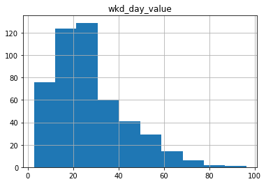

```python
print( "===================================================================")
print("3.")
print("Yes this is positively skewed, unlike the symmetrical normal distribution.")
# Plot the histogram of "wkd_day_value", i.e. ap["wkd_day_value"],
# is it skewed?
ap.hist("wkd_day_value")
```

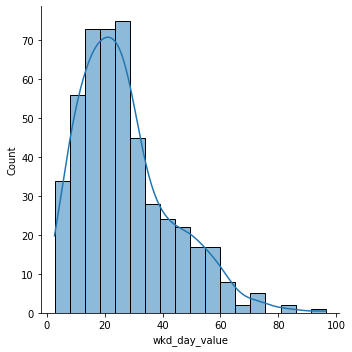

```python
sns.displot(ap,x="wkd_day_value",kde = True) # nicer :)
```

```python
print( "===================================================================")
print("4.")
# Write a function to calculate skewness. (Skewness = ∑𝑁𝑖(𝑋𝑖–𝑋𝑚𝑒𝑎𝑛)3/(𝑁−1)∗σ3)
# importing statistics to handle statistical operations

# loading massive amounts of modules for counter checks
import statistics as stats
import numpy as np
import scipy as sp

def skewness( object ):
    local_N = len(object)
    local_Mean = sum(object)/local_N

    # standards are the same but different
    local_Std = stats.stdev(object, local_Mean)
    local_npStd = np.std(object)

    skewd_Std = 0
    skewd_npStd = 0

    for i in range( 0, local_N, 1 ):
        skewd_Std += ( ( ( object[i]-local_Mean )**3 )
                            / ( ( local_N-1 ) * local_Std**3 ) )
        skewd_npStd += ( ( ( object[i]-local_Mean )**3 )
                            / ( ( local_N-1 ) * local_npStd**3 ) )

    return local_Std, skewd_Std, local_npStd, skewd_npStd

results = skewness(ap["wkd_day_value"])

print( "Using 'statistics' gives a standard deviation of", results[0], "\n and a skewness of", results[1], ".\n" )
print( "Using 'numpy' gives a standard deviation of", results[2], "\n and a skewness of", results[3], ".\n" )
print( "And according to 'scipy' the skewness is", sp.stats.skew(ap["wkd_day_value"]), ".\n")
print( "Further analyses should reveal if the results of the different approaches\nfollow a standard distribution or are skewed. All methods agree that there's\na positive skew, though.")
```

```
===================================================================
4.
Using 'statistics' gives a standard deviation of 16.037734417099177
 and a skewness of 1.0264905792191763 .

Using 'numpy' gives a standard deviation of 16.021089125206796
 and a skewness of 1.0296933564962365 .

And according to 'scipy' the skewness is 1.0275570632254987 .

Further analyses should reveal if the results of the different approaches
follow a standard distribution or are skewed. All methods agree that there's
a positive skew, though.
```